# Análisis Descriptivo información del portal de datos públicos de Medellín (MEData).

2024-11-13

# Lectura de la base de datos

```r
base_datos <- load_data("medata_1900_2022_debugged.csv", type = "interim")
```

# Agrupaciones para el análisis

```r
base_datos <- base_datos %>%
  mutate(def_naturaleza = recode(
    def_naturaleza,
    # violencia no sexual
    `1` = "Violencia física",
    `2` = "Violencia psicológica",
    `3` = "Negligencia y abandono",

    # violencia sexual
    `4` = "Violencia sexual",
    `5` = "Violencia sexual",
    `6` = "Violencia sexual",
    `7` = "Violencia sexual",
    `10` = "Violencia sexual",
    `12` = "Violencia sexual",
    `14` = "Violencia sexual"
  ))
```

# Análisis descriptivo

## Análisis temporal

```
##         Min.      1st Qu.       Median         Mean      3rd Qu.         Max.
## "1952-10-19" "2018-10-22" "2020-01-01" "2019-11-05" "2021-08-23" "2022-12-31"
```

Vemos que la fecha mínima para la **fecha de hecho** es 1952-10-19, mientras que el primer cuartil (Q1) es “2018-10-22”. Esto indica que al menos el 25% de los datos tienen fechas anteriores a “2018-10-22”, pero su distribución no es uniforme. Por otro lado, la media (2019-11-05) y la mediana (2020-01-01) sugieren que la mayoría de los registros se concentran en años recientes, lo que confirma que las fechas más antiguas podrían ser casos aislados o errores de registro. A continuación se ve un conteo de los casos presentados por año, y se ve que para años menores a 2017 los casos son muy pocos, por lo que se decide estudiar únicamente los casos cuyo año sea mayor o igual a 2017

```
##    Min. 1st Qu.  Median    Mean 3rd Qu.    Max.
##    1952    2018    2020    2019    2021    2022
```

| año_hecho | n |
| --- | --- |
| 1952 | 1 |
| 1956 | 1 |
| 1960 | 2 |
| 1962 | 2 |
| 1964 | 1 |
| 1965 | 1 |
| 1966 | 2 |
| 1967 | 1 |
| 1968 | 1 |
| 1969 | 5 |

[output cut: 53 more lines]

### Frecuencia de casos por año

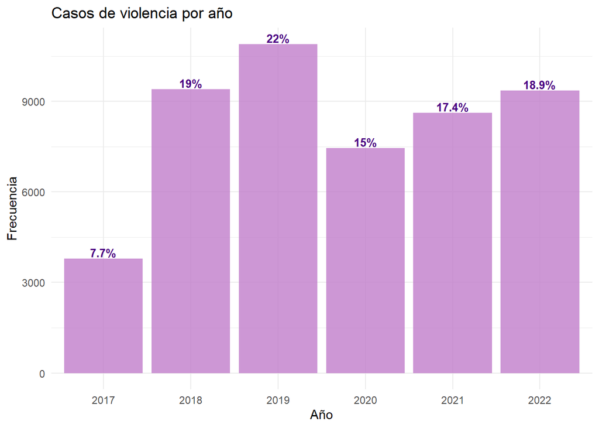